# Análise de Algoritmos

## Recorrência.

Função recursiva, aquela que chama a si mesmo:

Exemplo, cálculo fatorial em Python:

```python
fatorial = lambda n: 1 if n == 0 or n == 1 else n * fatorial(n-1)

print([fatorial(i) for  i in range(10)])
```

```
[1, 1, 2, 6, 24, 120, 720, 5040, 40320, 362880]
```

## Expansão Telescópica

Considere a relação de Recorrência:

$ T(n) = T(\frac{n}{2})+1$

Para resolver essa equação, aplicamos $T(\frac{n}{2})$ na fórmula de $T(n)$ e obtemos:

$T(\frac{n}{2}) = T(\frac{n}{4})+1$

$ T(n) = T(\frac{n}{2})+1$

$ T(n) = (T(\frac{n}{4})+1)+1$

$ T(n) = ((T(\frac{n}{8})+1)+1)+1$

...

$ T(n) = (...((((T(\frac{n}{2^k})+1+1)+1)+...+1)$

Vamos assumir que $n$ é uma potência de 2, logo $n=2^k$. Também consideramos que $T(n/2^k)=T(1) = 1$

Logo:

$ T(n) = (...((((T(\frac{n}{2^k})+1+1)+1)+...+1)$

$ T(n) = \sum_{i=1}^{k}{1}$

$ T(n) = k$

Mas: $n=2^k$. Fazendo o $\log_{2}$ nos dois lados da equação:

$\log_{2}(n) = \log_{2}{2^k}$

$\log_{2}(n) = k\log_{2}{2}$

$\log_{2}(n) = k$.

Ou seja:

$ T(n) = \log_{2}(n)$

Assim, a complexidade do algoritmo é $O(\log_{2}(n))$.

Asssumir $T(1) =1 $ é a chamada condição de parada, sendo 1 o valor base da recorrência, ou seja, o valor para o qual a recorrência é interrompida

E para o caso em que temos:

$T(n) = T(n/2) + n$, com $T(1)=$?

Expandimos a relação:

$T(n) = T(n/2) + n$

$T(n) = (T(n/4)+ n/2) + n$

$T(n) = ((T(n/8) + n/4)+n/2)+n$

...

$T(n) = (...((T(n/2^k) + n/2^{k-1})+n/2^{k-2})+...+n/2)+n$

Com $n = 2^{k}$

$T(n) = T(1) + 2+ 4 +8+16+...+2^{k}$

A partir da expansão anterior, podemos ver que um bom valor para $T(1)$ é 1, pois isso facilita o fechamento do somatório. Assim: $T(n) = 1 + 2+ 4 +8+16+...+2^{k}$

$T(n) = \sum_{i=0}^{k}2^{i}$

Isso é uma Progressão Geométrica de Ordem 2, com termo geral sendo $a_{k} = a_{1}q^{k-1}$.

A somatóra dos termos da PG é:

$S_{n} = \frac{a_{1}(q^{k}-1)}{q-1}$

Lembrando que $n=2^{k}$ implica em $k = \log_{2}(n)$, ou seja:

$T(n) = 2n-1$

Em princípio, toda relação de recorrência pode ser resolvida por expansão telescópia. Mas nesse caso é preciso achar a somatória conveniente para encontrar uma solução.

Podemos visualizar a recorrência através de uma árvore de recorrência. Vamos considerar a equação de recorrência para o algoritmo MergeSort:

$T(n) = 2T(n/2) + n$

$T(1)=$?

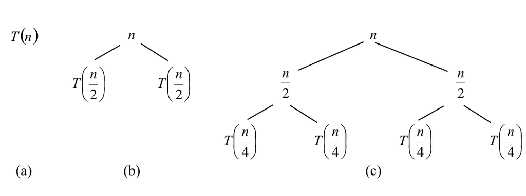

```python
Image(filename='./imagens/arvoreRecorrenciaA.png')
```

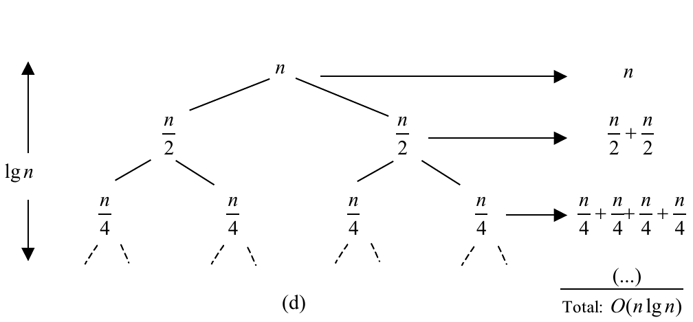

```python
Image(filename='./imagens/arvoreRecorrenciaB.png')
```

Com isso, basta achar a altura da árvore. Veja que a altura da árvore é $log_{n}$, mas o número de folhas é $n$, ou seja, o passo total será o número de folhas multiplicado pela altura da árvore.

Assim, a complexidade do algoritmos será: $O(n\log_{2}(n))$